# telecom_churn

```python
# import libraries
import pandas as pd
import numpy as np
import matplotlib.pyplot as plt
import seaborn as sns

import warnings
warnings.filterwarnings('ignore')

from IPython.core.interactiveshell import InteractiveShell
InteractiveShell.ast_node_interactivity = "all"
%matplotlib inline

pd.set_option("display.max_columns", 300)
pd.set_option("display.max_rows", 300)
```

```python
# read data
churn = pd.read_csv("telecom_data_for_students.csv")
```

```python
# look at initial rows of the data
churn.head(10)
```

|  | mobile_number | circle_id | loc_og_t2o_mou | std_og_t2o_mou | loc_ic_t2o_mou | last_date_of_month_6 | last_date_of_month_7 | last_date_of_month_8 | last_date_of_month_9 | arpu_6 | arpu_7 | arpu_8 | arpu_9 | onnet_mou_6 | onnet_mou_7 | onnet_mou_8 | onnet_mou_9 | offnet_mou_6 | offnet_mou_7 | offnet_mou_8 | offnet_mou_9 | roam_ic_mou_6 | roam_ic_mou_7 | roam_ic_mou_8 | roam_ic_mou_9 | roam_og_mou_6 | roam_og_mou_7 | roam_og_mou_8 | roam_og_mou_9 | … |
| --- | --- | --- | --- | --- | --- | --- | --- | --- | --- | --- | --- | --- | --- | --- | --- | --- | --- | --- | --- | --- | --- | --- | --- | --- | --- | --- | --- | --- | --- | --- |
| 0 | 7000842753 | 109 | 0.0 | 0.0 | 0.0 | 6/30/2014 | 7/31/2014 | 8/31/2014 | 9/30/2014 | 197.385 | 214.816 | 213.803 | 21.100 | NaN | NaN | 0.00 | NaN | NaN | NaN | 0.00 | NaN | NaN | NaN | 0.00 | NaN | NaN | NaN | 0.00 | NaN | … |
| 1 | 7001865778 | 109 | 0.0 | 0.0 | 0.0 | 6/30/2014 | 7/31/2014 | 8/31/2014 | 9/30/2014 | 34.047 | 355.074 | 268.321 | 86.285 | 24.11 | 78.68 | 7.68 | 18.34 | 15.74 | 99.84 | 304.76 | 53.76 | 0.00 | 0.00 | 0.00 | 0.00 | 0.00 | 0.00 | 0.00 | 0.00 | … |
| 2 | 7001625959 | 109 | 0.0 | 0.0 | 0.0 | 6/30/2014 | 7/31/2014 | 8/31/2014 | 9/30/2014 | 167.690 | 189.058 | 210.226 | 290.714 | 11.54 | 55.24 | 37.26 | 74.81 | 143.33 | 220.59 | 208.36 | 118.91 | 0.00 | 0.00 | 0.00 | 38.49 | 0.00 | 0.00 | 0.00 | 70.94 | … |
| 3 | 7001204172 | 109 | 0.0 | 0.0 | 0.0 | 6/30/2014 | 7/31/2014 | 8/31/2014 | 9/30/2014 | 221.338 | 251.102 | 508.054 | 389.500 | 99.91 | 54.39 | 310.98 | 241.71 | 123.31 | 109.01 | 71.68 | 113.54 | 0.00 | 54.86 | 44.38 | 0.00 | 0.00 | 28.09 | 39.04 | 0.00 | … |
| 4 | 7000142493 | 109 | 0.0 | 0.0 | 0.0 | 6/30/2014 | 7/31/2014 | 8/31/2014 | 9/30/2014 | 261.636 | 309.876 | 238.174 | 163.426 | 50.31 | 149.44 | 83.89 | 58.78 | 76.96 | 91.88 | 124.26 | 45.81 | 0.00 | 0.00 | 0.00 | 0.00 | 0.00 | 0.00 | 0.00 | 0.00 | … |
| 5 | 7000286308 | 109 | 0.0 | 0.0 | 0.0 | 6/30/2014 | 7/31/2014 | 8/31/2014 | 9/30/2014 | 50.258 | 58.810 | 83.386 | 170.826 | 50.16 | 43.63 | 85.48 | 138.79 | 19.28 | 13.44 | 14.46 | 46.91 | 0.00 | 0.00 | 0.00 | 0.00 | 0.00 | 0.00 | 0.00 | 0.00 | … |
| 6 | 7001051193 | 109 | 0.0 | 0.0 | 0.0 | 6/30/2014 | 7/31/2014 | 8/31/2014 | 9/30/2014 | 429.023 | 190.704 | 255.114 | 114.751 | 71.03 | 45.03 | 76.66 | 15.23 | 262.73 | 49.24 | 92.08 | 50.33 | 0.00 | 0.00 | 0.00 | 0.00 | 0.00 | 0.00 | 0.00 | 0.00 | … |
| 7 | 7000701601 | 109 | 0.0 | 0.0 | 0.0 | 6/30/2014 | 7/31/2014 | 8/31/2014 | 9/30/2014 | 1069.180 | 1349.850 | 3171.480 | 500.000 | 57.84 | 54.68 | 52.29 | NaN | 453.43 | 567.16 | 325.91 | NaN | 16.23 | 33.49 | 31.64 | NaN | 23.74 | 12.59 | 38.06 | NaN | … |
| 8 | 7001524846 | 109 | 0.0 | 0.0 | 0.0 | 6/30/2014 | 7/31/2014 | 8/31/2014 | 9/30/2014 | 378.721 | 492.223 | 137.362 | 166.787 | 413.69 | 351.03 | 35.08 | 33.46 | 94.66 | 80.63 | 136.48 | 108.71 | 0.00 | 0.00 | 0.00 | 0.00 | 0.00 | 0.00 | 0.00 | 0.00 | … |
| 9 | 7001864400 | 109 | 0.0 | 0.0 | 0.0 | 6/30/2014 | 7/31/2014 | 8/31/2014 | 9/30/2014 | 119.518 | 247.435 | 170.231 | 160.042 | 33.89 | 30.11 | 22.43 | 27.84 | 63.48 | 54.16 | 78.34 | 123.48 | 0.00 | 0.00 | 0.00 | 0.00 | 0.00 | 0.00 | 0.00 | 0.00 | … |

```python
# feature type summary
churn.info(verbose=1)
```

```
<class 'pandas.core.frame.DataFrame'>
RangeIndex: 99999 entries, 0 to 99998
Data columns (total 226 columns):
mobile_number               int64
circle_id                   int64
loc_og_t2o_mou              float64
std_og_t2o_mou              float64
loc_ic_t2o_mou              float64
last_date_of_month_6        object
last_date_of_month_7        object
last_date_of_month_8        object
last_date_of_month_9        object
arpu_6                      float64
arpu_7                      float64
arpu_8                      float64
arpu_9                      float64
onnet_mou_6                 float64
onnet_mou_7                 float64
onnet_mou_8                 float64
onnet_mou_9                 float64
offnet_mou_6                float64
offnet_mou_7                float64
offnet_mou_8                float64
offnet_mou_9                float64
roam_ic_mou_6               float64
roam_ic_mou_7               float64
roam_ic_mou_8               float64
roam_ic_mou_9               float64
roam_og_mou_6               float64
roam_og_mou_7               float64
roam_og_mou_8               float64
roam_og_mou_9               float64
loc_og_t2t_mou_6            float64
loc_og_t2t_mou_7            float64
loc_og_t2t_mou_8            float64
loc_og_t2t_mou_9            float64
loc_og_t2m_mou_6            float64
loc_og_t2m_mou_7            float64
loc_og_t2m_mou_8            float64
loc_og_t2m_mou_9            float64
```

[output cut: 176 more lines]

```
sachet_3g_6                 int64
sachet_3g_7                 int64
sachet_3g_8                 int64
sachet_3g_9                 int64
fb_user_6                   float64
fb_user_7                   float64
fb_user_8                   float64
fb_user_9                   float64
aon                         int64
aug_vbc_3g                  float64
jul_vbc_3g                  float64
jun_vbc_3g                  float64
sep_vbc_3g                  float64
dtypes: float64(179), int64(35), object(12)
memory usage: 172.4+ MB
```

There are 99999 rows and 226 columns in the data. Lot of the columns are numeric type, but we need to inspect which are the categorical columns.

```python
# look at data statistics
churn.describe(include='all')
```

|  | mobile_number | circle_id | loc_og_t2o_mou | std_og_t2o_mou | loc_ic_t2o_mou | last_date_of_month_6 | last_date_of_month_7 | last_date_of_month_8 | last_date_of_month_9 | arpu_6 | arpu_7 | arpu_8 | arpu_9 | onnet_mou_6 | onnet_mou_7 | onnet_mou_8 | onnet_mou_9 | offnet_mou_6 | offnet_mou_7 | offnet_mou_8 | offnet_mou_9 | roam_ic_mou_6 | roam_ic_mou_7 | roam_ic_mou_8 | roam_ic_mou_9 | roam_og_mou_6 | roam_og_mou_7 | roam_og_mou_8 | roam_og_mou_9 | … |
| --- | --- | --- | --- | --- | --- | --- | --- | --- | --- | --- | --- | --- | --- | --- | --- | --- | --- | --- | --- | --- | --- | --- | --- | --- | --- | --- | --- | --- | --- | --- |
| count | 9.999900e+04 | 99999.0 | 98981.0 | 98981.0 | 98981.0 | 99999 | 99398 | 98899 | 98340 | 99999.000000 | 99999.000000 | 99999.000000 | 99999.000000 | 96062.000000 | 96140.000000 | 94621.000000 | 92254.000000 | 96062.000000 | 96140.000000 | 94621.000000 | 92254.000000 | 96062.000000 | 96140.000000 | 94621.000000 | 92254.000000 | 96062.000000 | 96140.000000 | 94621.000000 | 92254.000000 | … |
| unique | NaN | NaN | NaN | NaN | NaN | 1 | 1 | 1 | 1 | NaN | NaN | NaN | NaN | NaN | NaN | NaN | NaN | NaN | NaN | NaN | NaN | NaN | NaN | NaN | NaN | NaN | NaN | NaN | NaN | … |
| top | NaN | NaN | NaN | NaN | NaN | 6/30/2014 | 7/31/2014 | 8/31/2014 | 9/30/2014 | NaN | NaN | NaN | NaN | NaN | NaN | NaN | NaN | NaN | NaN | NaN | NaN | NaN | NaN | NaN | NaN | NaN | NaN | NaN | NaN | … |
| freq | NaN | NaN | NaN | NaN | NaN | 99999 | 99398 | 98899 | 98340 | NaN | NaN | NaN | NaN | NaN | NaN | NaN | NaN | NaN | NaN | NaN | NaN | NaN | NaN | NaN | NaN | NaN | NaN | NaN | NaN | … |
| mean | 7.001207e+09 | 109.0 | 0.0 | 0.0 | 0.0 | NaN | NaN | NaN | NaN | 282.987358 | 278.536648 | 279.154731 | 261.645069 | 132.395875 | 133.670805 | 133.018098 | 130.302327 | 197.935577 | 197.045133 | 196.574803 | 190.337222 | 9.950013 | 7.149898 | 7.292981 | 6.343841 | 13.911337 | 9.818732 | 9.971890 | 8.555519 | … |
| std | 6.956694e+05 | 0.0 | 0.0 | 0.0 | 0.0 | NaN | NaN | NaN | NaN | 328.439770 | 338.156291 | 344.474791 | 341.998630 | 297.207406 | 308.794148 | 308.951589 | 308.477668 | 316.851613 | 325.862803 | 327.170662 | 319.396092 | 72.825411 | 73.447948 | 68.402466 | 57.137537 | 71.443196 | 58.455762 | 64.713221 | 58.438186 | … |
| min | 7.000000e+09 | 109.0 | 0.0 | 0.0 | 0.0 | NaN | NaN | NaN | NaN | -2258.709000 | -2014.045000 | -945.808000 | -1899.505000 | 0.000000 | 0.000000 | 0.000000 | 0.000000 | 0.000000 | 0.000000 | 0.000000 | 0.000000 | 0.000000 | 0.000000 | 0.000000 | 0.000000 | 0.000000 | 0.000000 | 0.000000 | 0.000000 | … |
| 25% | 7.000606e+09 | 109.0 | 0.0 | 0.0 | 0.0 | NaN | NaN | NaN | NaN | 93.411500 | 86.980500 | 84.126000 | 62.685000 | 7.380000 | 6.660000 | 6.460000 | 5.330000 | 34.730000 | 32.190000 | 31.630000 | 27.130000 | 0.000000 | 0.000000 | 0.000000 | 0.000000 | 0.000000 | 0.000000 | 0.000000 | 0.000000 | … |
| 50% | 7.001205e+09 | 109.0 | 0.0 | 0.0 | 0.0 | NaN | NaN | NaN | NaN | 197.704000 | 191.640000 | 192.080000 | 176.849000 | 34.310000 | 32.330000 | 32.360000 | 29.840000 | 96.310000 | 91.735000 | 92.140000 | 87.290000 | 0.000000 | 0.000000 | 0.000000 | 0.000000 | 0.000000 | 0.000000 | 0.000000 | 0.000000 | … |
| 75% | 7.001812e+09 | 109.0 | 0.0 | 0.0 | 0.0 | NaN | NaN | NaN | NaN | 371.060000 | 365.344500 | 369.370500 | 353.466500 | 118.740000 | 115.595000 | 115.860000 | 112.130000 | 231.860000 | 226.815000 | 228.260000 | 220.505000 | 0.000000 | 0.000000 | 0.000000 | 0.000000 | 0.000000 | 0.000000 | 0.000000 | 0.000000 | … |
| max | 7.002411e+09 | 109.0 | 0.0 | 0.0 | 0.0 | NaN | NaN | NaN | NaN | 27731.088000 | 35145.834000 | 33543.624000 | 38805.617000 | 7376.710000 | 8157.780000 | 10752.560000 | 10427.460000 | 8362.360000 | 9667.130000 | 14007.340000 | 10310.760000 | 13724.380000 | 15371.040000 | 13095.360000 | 8464.030000 | 3775.110000 | 2812.040000 | 5337.040000 | 4428.460000 | … |

```python
# create backup of data
original = churn.copy()
```

```python
# create column name list by types of columns
id_cols = ['mobile_number', 'circle_id']

date_cols = ['last_date_of_month_6',
             'last_date_of_month_7',
             'last_date_of_month_8',
             'last_date_of_month_9',
             'date_of_last_rech_6',
             'date_of_last_rech_7',
             'date_of_last_rech_8',
             'date_of_last_rech_9',
             'date_of_last_rech_data_6',
             'date_of_last_rech_data_7',
             'date_of_last_rech_data_8',
             'date_of_last_rech_data_9'
            ]

cat_cols =  ['night_pck_user_6',
             'night_pck_user_7',
             'night_pck_user_8',
             'night_pck_user_9',
             'fb_user_6',
             'fb_user_7',
             'fb_user_8',
             'fb_user_9'
            ]

num_cols = [column for column in churn.columns if column not in id_cols + date_cols + cat_cols]

# print the number of columns in each list
print("#ID cols: %d\n#Date cols:%d\n#Numeric cols:%d\n#Category cols:%d" % (len(id_cols), len(date_cols), len(num_cols), len(cat_cols)))

# check if we have missed any column or not
print(len(id_cols) + len(date_cols) + len(num_cols) + len(cat_cols) == churn.shape[1])
```

```
#ID cols: 2
#Date cols:12
#Numeric cols:204
#Category cols:8
True
```

# Handling missing values

```python
# look at missing value ratio in each column
churn.isnull().sum()*100/churn.shape[0]
```

```
mobile_number                0.000000
circle_id                    0.000000
loc_og_t2o_mou               1.018010
std_og_t2o_mou               1.018010
loc_ic_t2o_mou               1.018010
last_date_of_month_6         0.000000
last_date_of_month_7         0.601006
last_date_of_month_8         1.100011
last_date_of_month_9         1.659017
arpu_6                       0.000000
arpu_7                       0.000000
arpu_8                       0.000000
arpu_9                       0.000000
onnet_mou_6                  3.937039
onnet_mou_7                  3.859039
onnet_mou_8                  5.378054
onnet_mou_9                  7.745077
offnet_mou_6                 3.937039
offnet_mou_7                 3.859039
offnet_mou_8                 5.378054
offnet_mou_9                 7.745077
roam_ic_mou_6                3.937039
roam_ic_mou_7                3.859039
roam_ic_mou_8                5.378054
roam_ic_mou_9                7.745077
roam_og_mou_6                3.937039
roam_og_mou_7                3.859039
roam_og_mou_8                5.378054
roam_og_mou_9                7.745077
loc_og_t2t_mou_6             3.937039
loc_og_t2t_mou_7             3.859039
loc_og_t2t_mou_8             5.378054
loc_og_t2t_mou_9             7.745077
loc_og_t2m_mou_6             3.937039
loc_og_t2m_mou_7             3.859039
loc_og_t2m_mou_8             5.378054
loc_og_t2m_mou_9             7.745077
loc_og_t2f_mou_6             3.937039
loc_og_t2f_mou_7             3.859039
loc_og_t2f_mou_8             5.378054
```

[output cut: 172 more lines]

```
monthly_3g_9                 0.000000
sachet_3g_6                  0.000000
sachet_3g_7                  0.000000
sachet_3g_8                  0.000000
sachet_3g_9                  0.000000
fb_user_6                   74.846748
fb_user_7                   74.428744
fb_user_8                   73.660737
fb_user_9                   74.077741
aon                          0.000000
aug_vbc_3g                   0.000000
jul_vbc_3g                   0.000000
jun_vbc_3g                   0.000000
sep_vbc_3g                   0.000000
dtype: float64
```

# impute missing values

## i) Imputing with zeroes

```python
# some recharge columns have minimum value of 1 while some don't
recharge_cols = ['total_rech_data_6', 'total_rech_data_7', 'total_rech_data_8', 'total_rech_data_9',
                 'count_rech_2g_6', 'count_rech_2g_7', 'count_rech_2g_8', 'count_rech_2g_9',
                 'count_rech_3g_6', 'count_rech_3g_7', 'count_rech_3g_8', 'count_rech_3g_9',
                 'max_rech_data_6', 'max_rech_data_7', 'max_rech_data_8', 'max_rech_data_9',
                 'av_rech_amt_data_6', 'av_rech_amt_data_7', 'av_rech_amt_data_8', 'av_rech_amt_data_9',
                 ]

churn[recharge_cols].describe(include='all')
```

|  | total_rech_data_6 | total_rech_data_7 | total_rech_data_8 | total_rech_data_9 | count_rech_2g_6 | count_rech_2g_7 | count_rech_2g_8 | count_rech_2g_9 | count_rech_3g_6 | count_rech_3g_7 | count_rech_3g_8 | count_rech_3g_9 | max_rech_data_6 | max_rech_data_7 | max_rech_data_8 | max_rech_data_9 | av_rech_amt_data_6 | av_rech_amt_data_7 | av_rech_amt_data_8 | av_rech_amt_data_9 |
| --- | --- | --- | --- | --- | --- | --- | --- | --- | --- | --- | --- | --- | --- | --- | --- | --- | --- | --- | --- | --- |
| count | 25153.000000 | 25571.000000 | 26339.000000 | 25922.000000 | 25153.000000 | 25571.000000 | 26339.000000 | 25922.000000 | 25153.000000 | 25571.000000 | 26339.000000 | 25922.000000 | 25153.000000 | 25571.000000 | 26339.000000 | 25922.00000 | 25153.000000 | 25571.000000 | 26339.000000 | 25922.000000 |
| mean | 2.463802 | 2.666419 | 2.651999 | 2.441170 | 1.864668 | 2.044699 | 2.016288 | 1.781807 | 0.599133 | 0.621720 | 0.635711 | 0.659363 | 126.393392 | 126.729459 | 125.717301 | 124.94144 | 192.600982 | 200.981292 | 197.526489 | 192.734315 |
| std | 2.789128 | 3.031593 | 3.074987 | 2.516339 | 2.570254 | 2.768332 | 2.720132 | 2.214701 | 1.274428 | 1.394524 | 1.422827 | 1.411513 | 108.477235 | 109.765267 | 109.437851 | 111.36376 | 192.646318 | 196.791224 | 191.301305 | 188.400286 |
| min | 1.000000 | 1.000000 | 1.000000 | 1.000000 | 0.000000 | 0.000000 | 0.000000 | 0.000000 | 0.000000 | 0.000000 | 0.000000 | 0.000000 | 1.000000 | 1.000000 | 1.000000 | 1.00000 | 1.000000 | 0.500000 | 0.500000 | 1.000000 |
| 25% | 1.000000 | 1.000000 | 1.000000 | 1.000000 | 1.000000 | 1.000000 | 1.000000 | 1.000000 | 0.000000 | 0.000000 | 0.000000 | 0.000000 | 25.000000 | 25.000000 | 25.000000 | 25.00000 | 82.000000 | 92.000000 | 87.000000 | 69.000000 |
| 50% | 1.000000 | 1.000000 | 1.000000 | 2.000000 | 1.000000 | 1.000000 | 1.000000 | 1.000000 | 0.000000 | 0.000000 | 0.000000 | 0.000000 | 145.000000 | 145.000000 | 145.000000 | 145.00000 | 154.000000 | 154.000000 | 154.000000 | 164.000000 |
| 75% | 3.000000 | 3.000000 | 3.000000 | 3.000000 | 2.000000 | 2.000000 | 2.000000 | 2.000000 | 1.000000 | 1.000000 | 1.000000 | 1.000000 | 177.000000 | 177.000000 | 179.000000 | 179.00000 | 252.000000 | 252.000000 | 252.000000 | 252.000000 |
| max | 61.000000 | 54.000000 | 60.000000 | 84.000000 | 42.000000 | 48.000000 | 44.000000 | 40.000000 | 29.000000 | 35.000000 | 45.000000 | 49.000000 | 1555.000000 | 1555.000000 | 1555.000000 | 1555.00000 | 7546.000000 | 4365.000000 | 4076.000000 | 4061.000000 |

```python
# It is also observed that the recharge date and the recharge value are missing together which means the customer didn't recharge
churn.loc[churn.total_rech_data_6.isnull() & churn.date_of_last_rech_data_6.isnull(), ["total_rech_data_6", "date_of_last_rech_data_6"]].head(20)
```

|  | total_rech_data_6 | date_of_last_rech_data_6 |
| --- | --- | --- |
| 1 | NaN | NaN |
| 2 | NaN | NaN |
| 3 | NaN | NaN |
| 5 | NaN | NaN |
| 6 | NaN | NaN |
| 7 | NaN | NaN |
| 8 | NaN | NaN |
| 9 | NaN | NaN |
| 10 | NaN | NaN |
| 11 | NaN | NaN |
| 12 | NaN | NaN |
| 13 | NaN | NaN |
| 14 | NaN | NaN |
| 15 | NaN | NaN |
| 16 | NaN | NaN |
| 17 | NaN | NaN |
| 18 | NaN | NaN |
| 20 | NaN | NaN |
| 21 | NaN | NaN |
| 22 | NaN | NaN |

In the recharge variables where minumum value is 1, we can impute missing values with zeroes since it means customer didn't recharge their numbere that month.

```python
# create a list of recharge columns where we will impute missing values with zeroes
zero_impute = ['total_rech_data_6', 'total_rech_data_7', 'total_rech_data_8', 'total_rech_data_9',
        'av_rech_amt_data_6', 'av_rech_amt_data_7', 'av_rech_amt_data_8', 'av_rech_amt_data_9',
        'max_rech_data_6', 'max_rech_data_7', 'max_rech_data_8', 'max_rech_data_9'
       ]
```

```python
# impute missing values with 0
churn[zero_impute] = churn[zero_impute].apply(lambda x: x.fillna(0))
```

```python
# now, let's make sure values are imputed correctly
print("Missing value ratio:\n")
print(churn[zero_impute].isnull().sum()*100/churn.shape[1])

# summary
print("\n\nSummary statistics\n")
print(churn[zero_impute].describe(include='all'))
```

```
Missing value ratio:

total_rech_data_6     0.0
total_rech_data_7     0.0
total_rech_data_8     0.0
total_rech_data_9     0.0
av_rech_amt_data_6    0.0
av_rech_amt_data_7    0.0
av_rech_amt_data_8    0.0
av_rech_amt_data_9    0.0
max_rech_data_6       0.0
max_rech_data_7       0.0
max_rech_data_8       0.0
max_rech_data_9       0.0
dtype: float64


Summary statistics

       total_rech_data_6  total_rech_data_7  total_rech_data_8  \
count       99999.000000       99999.000000       99999.000000
mean            0.619726           0.681837           0.698517
std             1.760541           1.924382           1.963417
min             0.000000           0.000000           0.000000
25%             0.000000           0.000000           0.000000
50%             0.000000           0.000000           0.000000
75%             1.000000           1.000000           1.000000
max            61.000000          54.000000          60.000000

       total_rech_data_9  av_rech_amt_data_6  av_rech_amt_data_7  \
count       99999.000000        99999.000000        99999.000000
mean            0.632806           48.445409           51.393440
std             1.669040          127.743863          132.629365
min             0.000000            0.000000            0.000000
25%             0.000000            0.000000            0.000000
50%             0.000000            0.000000            0.000000
75%             1.000000            8.250000           17.000000
max            84.000000         7546.000000         4365.000000

       av_rech_amt_data_8  av_rech_amt_data_9  max_rech_data_6  \
count        99999.000000        99999.000000     99999.000000
mean            52.027022           49.961089        31.792048
std            131.182609          127.804280        77.248778
min              0.000000            0.000000         0.000000
25%              0.000000            0.000000         0.000000
50%              0.000000            0.000000         0.000000
75%             23.000000           17.000000         8.000000
max           4076.000000         4061.000000      1555.000000

       max_rech_data_7  max_rech_data_8  max_rech_data_9
count     99999.000000     99999.000000     99999.000000
mean         32.406314        33.113011        32.387644
std          78.342435        78.872739        78.818696
min           0.000000         0.000000         0.000000
25%           0.000000         0.000000         0.000000
50%           0.000000         0.000000         0.000000
75%          14.000000        17.000000        17.000000
max        1555.000000      1555.000000      1555.000000
```

```python
# drop id and date columns
print("Shape before dropping: ", churn.shape)
churn = churn.drop(id_cols + date_cols, axis=1)
print("Shape after dropping: ", churn.shape)
```

```
Shape before dropping:  (99999, 226)
Shape after dropping:  (99999, 212)
```

## ii) Replace NaN values in categorical variables

```python
# replace missing values with '-1' in categorical columns
churn[cat_cols] = churn[cat_cols].apply(lambda x: x.fillna(-1))
```

```python
# missing value ratio
print("Missing value ratio:\n")
print(churn[cat_cols].isnull().sum()*100/churn.shape[0])
```

```
Missing value ratio:

night_pck_user_6    0.0
night_pck_user_7    0.0
night_pck_user_8    0.0
night_pck_user_9    0.0
fb_user_6           0.0
fb_user_7           0.0
fb_user_8           0.0
fb_user_9           0.0
dtype: float64
```

## iii) Drop variables with more than a given threshold of missing values

```python
initial_cols = churn.shape[1]

MISSING_THRESHOLD = 0.7

include_cols = list(churn.apply(lambda column: True if column.isnull().sum()/churn.shape[0] < MISSING_THRESHOLD else False))

drop_missing = pd.DataFrame({'features':churn.columns , 'include': include_cols})
drop_missing.loc[drop_missing.include == True,:]
```

|  | features | include |
| --- | --- | --- |
| 0 | loc_og_t2o_mou | True |
| 1 | std_og_t2o_mou | True |
| 2 | loc_ic_t2o_mou | True |
| 3 | arpu_6 | True |
| 4 | arpu_7 | True |
| 5 | arpu_8 | True |
| 6 | arpu_9 | True |
| 7 | onnet_mou_6 | True |
| 8 | onnet_mou_7 | True |
| 9 | onnet_mou_8 | True |
| 10 | onnet_mou_9 | True |
| 11 | offnet_mou_6 | True |
| 12 | offnet_mou_7 | True |
| 13 | offnet_mou_8 | True |
| 14 | offnet_mou_9 | True |
| 15 | roam_ic_mou_6 | True |
| 16 | roam_ic_mou_7 | True |
| 17 | roam_ic_mou_8 | True |
| 18 | roam_ic_mou_9 | True |
| 19 | roam_og_mou_6 | True |
| 20 | roam_og_mou_7 | True |
| 21 | roam_og_mou_8 | True |
| 22 | roam_og_mou_9 | True |
| 23 | loc_og_t2t_mou_6 | True |
| 24 | loc_og_t2t_mou_7 | True |
| 25 | loc_og_t2t_mou_8 | True |
| 26 | loc_og_t2t_mou_9 | True |
| 27 | loc_og_t2m_mou_6 | True |
| 28 | loc_og_t2m_mou_7 | True |
| 29 | loc_og_t2m_mou_8 | True |

[output cut: 166 more lines]

```python
# drop columns
churn = churn.loc[:, include_cols]

dropped_cols = churn.shape[1] - initial_cols
print("{0} columns dropped.".format(dropped_cols))
```

```
-16 columns dropped.
```

## iv) imputing using MICE

using fancyimpute package from [here](https://github.com/iskandr/fancyimpute)

```python
churn_cols = churn.columns

# using MICE technique to impute missing values in the rest of the columns
from fancyimpute import MICE
churn_imputed = MICE(n_imputations=1).complete(churn)
```

```
[MICE] Completing matrix with shape (99999, 196)
[MICE] Starting imputation round 1/11, elapsed time 0.887
[MICE] Starting imputation round 2/11, elapsed time 176.649
[MICE] Starting imputation round 3/11, elapsed time 343.774
[MICE] Starting imputation round 4/11, elapsed time 507.450
[MICE] Starting imputation round 5/11, elapsed time 677.217
[MICE] Starting imputation round 6/11, elapsed time 839.576
[MICE] Starting imputation round 7/11, elapsed time 1001.674
[MICE] Starting imputation round 8/11, elapsed time 1174.182
[MICE] Starting imputation round 9/11, elapsed time 1369.406
[MICE] Starting imputation round 10/11, elapsed time 1534.524
[MICE] Starting imputation round 11/11, elapsed time 1683.410
```

```python
# convert imputed numpy array to pandas dataframe
churn = pd.DataFrame(churn_imputed, columns=churn_cols)
print(churn.isnull().sum()*100/churn.shape[0])
```

```
loc_og_t2o_mou        0.0
std_og_t2o_mou        0.0
loc_ic_t2o_mou        0.0
arpu_6                0.0
arpu_7                0.0
arpu_8                0.0
arpu_9                0.0
onnet_mou_6           0.0
onnet_mou_7           0.0
onnet_mou_8           0.0
onnet_mou_9           0.0
offnet_mou_6          0.0
offnet_mou_7          0.0
offnet_mou_8          0.0
offnet_mou_9          0.0
roam_ic_mou_6         0.0
roam_ic_mou_7         0.0
roam_ic_mou_8         0.0
roam_ic_mou_9         0.0
roam_og_mou_6         0.0
roam_og_mou_7         0.0
roam_og_mou_8         0.0
roam_og_mou_9         0.0
loc_og_t2t_mou_6      0.0
loc_og_t2t_mou_7      0.0
loc_og_t2t_mou_8      0.0
loc_og_t2t_mou_9      0.0
loc_og_t2m_mou_6      0.0
loc_og_t2m_mou_7      0.0
loc_og_t2m_mou_8      0.0
loc_og_t2m_mou_9      0.0
loc_og_t2f_mou_6      0.0
loc_og_t2f_mou_7      0.0
loc_og_t2f_mou_8      0.0
loc_og_t2f_mou_9      0.0
loc_og_t2c_mou_6      0.0
loc_og_t2c_mou_7      0.0
loc_og_t2c_mou_8      0.0
loc_og_t2c_mou_9      0.0
loc_og_mou_6          0.0
```

[output cut: 142 more lines]

```
monthly_3g_9          0.0
sachet_3g_6           0.0
sachet_3g_7           0.0
sachet_3g_8           0.0
sachet_3g_9           0.0
fb_user_6             0.0
fb_user_7             0.0
fb_user_8             0.0
fb_user_9             0.0
aon                   0.0
aug_vbc_3g            0.0
jul_vbc_3g            0.0
jun_vbc_3g            0.0
sep_vbc_3g            0.0
dtype: float64
```

# filter high-value customers

### calculate total data recharge amount

```python
# calculate the total data recharge amount for June and July --> number of recharges * average recharge amount
churn['total_data_rech_6'] = churn.total_rech_data_6 * churn.av_rech_amt_data_6
churn['total_data_rech_7'] = churn.total_rech_data_7 * churn.av_rech_amt_data_7
```

### add total data recharge and total recharge to get total combined recharge amount for a month

```python
# calculate total recharge amount for June and July --> call recharge amount + data recharge amount
churn['amt_data_6'] = churn.total_rech_amt_6 + churn.total_data_rech_6
churn['amt_data_7'] = churn.total_rech_amt_7 + churn.total_data_rech_7
```

```python
# calculate average recharge done by customer in June and July
churn['av_amt_data_6_7'] = (churn.amt_data_6 + churn.amt_data_7)/2
```

```python
# look at the 70th percentile recharge amount
print("Recharge amount at 70th percentile: {0}".format(churn.av_amt_data_6_7.quantile(0.7)))
```

```
Recharge amount at 70th percentile: 478.0
```

```python
# retain only those customers who have recharged their mobiles with more than or equal to 70th percentile amount
churn_filtered = churn.loc[churn.av_amt_data_6_7 >= churn.av_amt_data_6_7.quantile(0.7), :]
churn_filtered = churn_filtered.reset_index(drop=True)
churn_filtered.shape
```

```
(30001, 201)
```

```python
# delete variables created to filter high-value customers
churn_filtered = churn_filtered.drop(['total_data_rech_6', 'total_data_rech_7',
                                      'amt_data_6', 'amt_data_7', 'av_amt_data_6_7'], axis=1)
churn_filtered.shape
```

```
(30001, 196)
```

# derive churn

```python
# calculate total incoming and outgoing minutes of usage
churn_filtered['total_calls_mou_9'] = churn_filtered.total_ic_mou_9 + churn_filtered.total_og_mou_9
```

```python
# calculate 2g and 3g data consumption
churn_filtered['total_internet_mb_9'] =  churn_filtered.vol_2g_mb_9 + churn_filtered.vol_3g_mb_9
```

```python
# create churn variable: those who have not used either calls or internet in the month of September are customers who have churned

# 0 - not churn, 1 - churn
churn_filtered['churn'] = churn_filtered.apply(lambda row: 1 if (row.total_calls_mou_9 == 0 and row.total_internet_mb_9 == 0) else 0, axis=1)
```

```python
# delete derived variables
churn_filtered = churn_filtered.drop(['total_calls_mou_9', 'total_internet_mb_9'], axis=1)
```

```python
# change data type to category
churn_filtered.churn = churn_filtered.churn.astype("category")

# print churn ratio
print("Churn Ratio:")
print(churn_filtered.churn.value_counts()*100/churn_filtered.shape[0])
```

```
Churn Ratio:
0    91.863605
1     8.136395
Name: churn, dtype: float64
```

# Calculate difference between 8th and previous months

Let's derive some variables. The most important feature, in this situation, can be the difference between the 8th month and the previous months. The difference can be in patterns such as usage difference or recharge value difference. Let's calculate difference variable as the difference between 8th month and the average of 6th and 7th month.

```python
churn_filtered['arpu_diff'] = churn_filtered.arpu_8 - ((churn_filtered.arpu_6 + churn_filtered.arpu_7)/2)

churn_filtered['onnet_mou_diff'] = churn_filtered.onnet_mou_8 - ((churn_filtered.onnet_mou_6 + churn_filtered.onnet_mou_7)/2)

churn_filtered['offnet_mou_diff'] = churn_filtered.offnet_mou_8 - ((churn_filtered.offnet_mou_6 + churn_filtered.offnet_mou_7)/2)

churn_filtered['roam_ic_mou_diff'] = churn_filtered.roam_ic_mou_8 - ((churn_filtered.roam_ic_mou_6 + churn_filtered.roam_ic_mou_7)/2)

churn_filtered['roam_og_mou_diff'] = churn_filtered.roam_og_mou_8 - ((churn_filtered.roam_og_mou_6 + churn_filtered.roam_og_mou_7)/2)

churn_filtered['loc_og_mou_diff'] = churn_filtered.loc_og_mou_8 - ((churn_filtered.loc_og_mou_6 + churn_filtered.loc_og_mou_7)/2)

churn_filtered['std_og_mou_diff'] = churn_filtered.std_og_mou_8 - ((churn_filtered.std_og_mou_6 + churn_filtered.std_og_mou_7)/2)

churn_filtered['isd_og_mou_diff'] = churn_filtered.isd_og_mou_8 - ((churn_filtered.isd_og_mou_6 + churn_filtered.isd_og_mou_7)/2)

churn_filtered['spl_og_mou_diff'] = churn_filtered.spl_og_mou_8 - ((churn_filtered.spl_og_mou_6 + churn_filtered.spl_og_mou_7)/2)

churn_filtered['total_og_mou_diff'] = churn_filtered.total_og_mou_8 - ((churn_filtered.total_og_mou_6 + churn_filtered.total_og_mou_7)/2)

churn_filtered['loc_ic_mou_diff'] = churn_filtered.loc_ic_mou_8 - ((churn_filtered.loc_ic_mou_6 + churn_filtered.loc_ic_mou_7)/2)

churn_filtered['std_ic_mou_diff'] = churn_filtered.std_ic_mou_8 - ((churn_filtered.std_ic_mou_6 + churn_filtered.std_ic_mou_7)/2)

churn_filtered['isd_ic_mou_diff'] = churn_filtered.isd_ic_mou_8 - ((churn_filtered.isd_ic_mou_6 + churn_filtered.isd_ic_mou_7)/2)

churn_filtered['spl_ic_mou_diff'] = churn_filtered.spl_ic_mou_8 - ((churn_filtered.spl_ic_mou_6 + churn_filtered.spl_ic_mou_7)/2)

churn_filtered['total_ic_mou_diff'] = churn_filtered.total_ic_mou_8 - ((churn_filtered.total_ic_mou_6 + churn_filtered.total_ic_mou_7)/2)

churn_filtered['total_rech_num_diff'] = churn_filtered.total_rech_num_8 - ((churn_filtered.total_rech_num_6 + churn_filtered.total_rech_num_7)/2)

churn_filtered['total_rech_amt_diff'] = churn_filtered.total_rech_amt_8 - ((churn_filtered.total_rech_amt_6 + churn_filtered.total_rech_amt_7)/2)

churn_filtered['max_rech_amt_diff'] = churn_filtered.max_rech_amt_8 - ((churn_filtered.max_rech_amt_6 + churn_filtered.max_rech_amt_7)/2)

churn_filtered['total_rech_data_diff'] = churn_filtered.total_rech_data_8 - ((churn_filtered.total_rech_data_6 + churn_filtered.total_rech_data_7)/2)

churn_filtered['max_rech_data_diff'] = churn_filtered.max_rech_data_8 - ((churn_filtered.max_rech_data_6 + churn_filtered.max_rech_data_7)/2)

churn_filtered['av_rech_amt_data_diff'] = churn_filtered.av_rech_amt_data_8 - ((churn_filtered.av_rech_amt_data_6 + churn_filtered.av_rech_amt_data_7)/2)

churn_filtered['vol_2g_mb_diff'] = churn_filtered.vol_2g_mb_8 - ((churn_filtered.vol_2g_mb_6 + churn_filtered.vol_2g_mb_7)/2)

churn_filtered['vol_3g_mb_diff'] = churn_filtered.vol_3g_mb_8 - ((churn_filtered.vol_3g_mb_6 + churn_filtered.vol_3g_mb_7)/2)
```

```python
# let's look at summary of one of the difference variables
churn_filtered['total_og_mou_diff'].describe()
```

```
count    30001.000000
mean       -67.437337
std        502.630069
min      -7213.410000
25%       -168.025000
50%        -14.625000
75%         67.915000
max      12768.705000
Name: total_og_mou_diff, dtype: float64
```

## delete columns that belong to the churn month (9th month)

```python
# delete all variables relating to 9th month
churn_filtered = churn_filtered.filter(regex='[^9]$', axis=1)
churn_filtered.shape
```

```
(30001, 173)
```

```python
# extract all names that end with 9
col_9_names = churn.filter(regex='9$', axis=1).columns

# update num_cols and cat_cols column name list
cat_cols = [col for col in cat_cols if col not in col_9_names]
cat_cols.append('churn')
num_cols = [col for col in churn_filtered.columns if col not in cat_cols]
```

## visualise data

```python
# change columns types
churn_filtered[num_cols] = churn_filtered[num_cols].apply(pd.to_numeric)
churn_filtered[cat_cols] = churn_filtered[cat_cols].apply(lambda column: column.astype("category"), axis=0)
```

```python
# create plotting functions
def data_type(variable):
    if variable.dtype == np.int64 or variable.dtype == np.float64:
        return 'numerical'
    elif variable.dtype == 'category':
        return 'categorical'

def univariate(variable, stats=True):

    if data_type(variable) == 'numerical':
        sns.distplot(variable)
        if stats == True:
            print(variable.describe())

    elif data_type(variable) == 'categorical':
        sns.countplot(variable)
        if stats == True:
            print(variable.value_counts())

    else:
        print("Invalid variable passed: either pass a numeric variable or a categorical vairable.")

def bivariate(var1, var2):
    if data_type(var1) == 'numerical' and data_type(var2) == 'numerical':
        sns.regplot(var1, var2)
    elif (data_type(var1) == 'categorical' and data_type(var2) == 'numerical') or (data_type(var1) == 'numerical' and data_type(var2) == 'categorical'):
        sns.boxplot(var1, var2)
```

## Univariate EDA

```
count    99999.000000
mean       282.987358
std        328.439770
min      -2258.709000
25%         93.411500
50%        197.704000
75%        371.060000
max      27731.088000
Name: arpu_6, dtype: float64
```

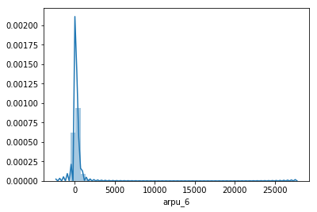

```python
univariate(churn.arpu_6)
```

```
count    99999.000000
mean        -0.000002
std          0.000312
min         -0.009873
25%          0.000000
50%          0.000000
75%          0.000000
max          0.009702
Name: loc_og_t2o_mou, dtype: float64
```

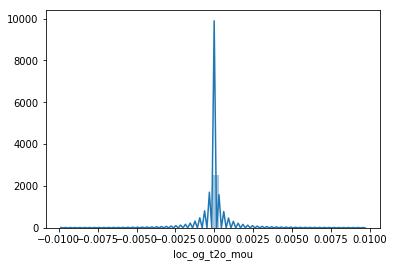

```python
univariate(churn.loc_og_t2o_mou)
```

```
count    9.999900e+04
mean    -9.957627e-07
std      3.136615e-04
min     -1.085887e-02
25%      0.000000e+00
50%      0.000000e+00
75%      0.000000e+00
max      9.418004e-03
Name: std_og_t2o_mou, dtype: float64
```

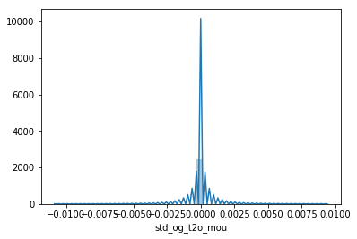

```python
univariate(churn.std_og_t2o_mou)
```

```
count    99999.000000
mean       125.972580
std        302.822628
min       -700.923704
25%          5.510000
50%         30.760000
75%        109.400000
max      10752.560000
Name: onnet_mou_8, dtype: float64
```

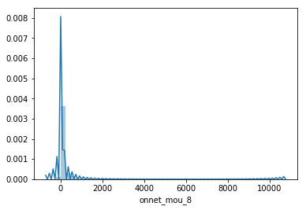

```python
univariate(churn.onnet_mou_8)
```

```
count    99999.000000
mean       176.085292
std        311.955151
min      -1407.015438
25%         21.903023
50%         78.360000
75%        204.270000
max      10310.760000
Name: offnet_mou_9, dtype: float64
```

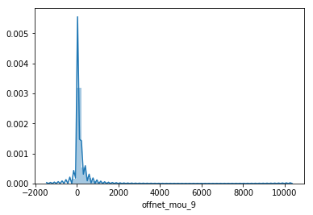

```python
univariate(churn.offnet_mou_9)
```

## Bivariate EDA

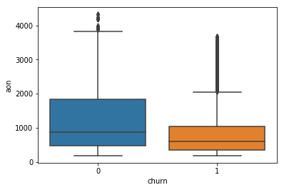

```python
bivariate(churn_filtered.churn, churn_filtered.aon)
```

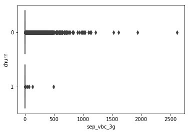

```python
bivariate(churn_filtered.sep_vbc_3g, churn_filtered.churn)
```

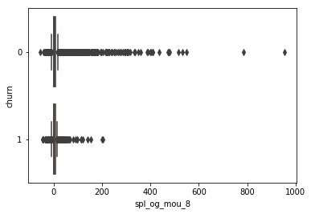

```python
bivariate(churn_filtered.spl_og_mou_8, churn_filtered.churn)
```

```python
pd.crosstab(churn_filtered.churn, churn_filtered.night_pck_user_8, normalize='columns')*100
```

| night_pck_user_8 churn | -1.0 | 0.0 | 1.0 |
| --- | --- | --- | --- |
| 0 | 85.89123 | 97.117602 | 97.360704 |
| 1 | 14.10877 | 2.882398 | 2.639296 |

```python
pd.crosstab(churn_filtered.churn, churn_filtered.sachet_3g_8)
```

| sachet_3g_8 churn | 0.0 | 1.0 | 2.0 | 3.0 | 4.0 | 5.0 | 6.0 | 7.0 | 8.0 | 9.0 | 10.0 | 11.0 | 12.0 | 13.0 | 14.0 | 15.0 | 16.0 | 17.0 | 18.0 | 19.0 | 20.0 | 21.0 | 23.0 | 25.0 | 27.0 | 29.0 | 30.0 | 38.0 | 41.0 |
| --- | --- | --- | --- | --- | --- | --- | --- | --- | --- | --- | --- | --- | --- | --- | --- | --- | --- | --- | --- | --- | --- | --- | --- | --- | --- | --- | --- | --- | --- |
| 0 | 24972 | 1609 | 399 | 184 | 106 | 86 | 43 | 35 | 28 | 19 | 15 | 8 | 11 | 10 | 6 | 6 | 2 | 2 | 3 | 1 | 3 | 3 | 2 | 1 | 1 | 1 | 2 | 1 | 1 |
| 1 | 2369 | 48 | 5 | 8 | 4 | 2 | 1 | 0 | 2 | 0 | 0 | 0 | 0 | 1 | 0 | 0 | 1 | 0 | 0 | 0 | 0 | 0 | 0 | 0 | 0 | 0 | 0 | 0 | 0 |

### Cap outliers in all numeric variables with k-sigma technique

```python
def cap_outliers(array, k=3):
    upper_limit = array.mean() + k*array.std()
    lower_limit = array.mean() - k*array.std()
    array[array<lower_limit] = lower_limit
    array[array>upper_limit] = upper_limit
    return array
```

```python
# example of capping
sample_array = list(range(100))

# add outliers to the data
sample_array[0] = -9999
sample_array[99] = 9999

# cap outliers
sample_array = np.array(sample_array)
print("Array after capping outliers: \n", cap_outliers(sample_array, k=2))
```

```
Array after capping outliers:
 [-2780     1     2     3     4     5     6     7     8     9    10    11
    12    13    14    15    16    17    18    19    20    21    22    23
    24    25    26    27    28    29    30    31    32    33    34    35
    36    37    38    39    40    41    42    43    44    45    46    47
    48    49    50    51    52    53    54    55    56    57    58    59
    60    61    62    63    64    65    66    67    68    69    70    71
    72    73    74    75    76    77    78    79    80    81    82    83
    84    85    86    87    88    89    90    91    92    93    94    95
    96    97    98  2877]
```

```python
# cap outliers in the numeric columns
churn_filtered[num_cols] = churn_filtered[num_cols].apply(cap_outliers, axis=0)
```

# Modelling

```python
# import required libraries
from sklearn.model_selection import train_test_split
from sklearn.pipeline import Pipeline
from sklearn.decomposition import PCA
from sklearn.preprocessing import StandardScaler
from sklearn.pipeline import FeatureUnion
from sklearn.base import BaseEstimator, TransformerMixin
from sklearn.linear_model import LogisticRegression
from sklearn.metrics import classification_report
from sklearn.metrics import roc_auc_score
from imblearn.metrics import sensitivity_specificity_support
from sklearn.model_selection import StratifiedKFold
from sklearn.model_selection import cross_val_score
from sklearn.metrics import confusion_matrix
from sklearn.model_selection import GridSearchCV
from sklearn.ensemble import RandomForestClassifier
from sklearn.ensemble import GradientBoostingClassifier
from sklearn.svm import SVC
```

## Preprocessing data

```python
# change churn to numeric
churn_filtered['churn'] = pd.to_numeric(churn_filtered['churn'])
```

### Train Test split

```python
# divide data into train and test
X = churn_filtered.drop("churn", axis = 1)
y = churn_filtered.churn
X_train, X_test, y_train, y_test = train_test_split(X, y, test_size = 0.25, random_state = 4, stratify = y)
```

```python
# print shapes of train and test sets
X_train.shape
y_train.shape
X_test.shape
y_test.shape
```

```
(22500, 172)
```

```
(22500,)
```

```
(7501, 172)
```

```
(7501,)
```

## Aggregating the categorical columns

```python
train = pd.concat([X_train, y_train], axis=1)

# aggregate the categorical variables
train.groupby('night_pck_user_6').churn.mean()
train.groupby('night_pck_user_7').churn.mean()
train.groupby('night_pck_user_8').churn.mean()
train.groupby('fb_user_6').churn.mean()
train.groupby('fb_user_7').churn.mean()
train.groupby('fb_user_8').churn.mean()
```

```
night_pck_user_6
-1.0    0.099165
 0.0    0.066797
 1.0    0.087838
Name: churn, dtype: float64
```

```
night_pck_user_7
-1.0    0.115746
 0.0    0.055494
 1.0    0.051282
Name: churn, dtype: float64
```

```
night_pck_user_8
-1.0    0.141108
 0.0    0.029023
 1.0    0.016194
Name: churn, dtype: float64
```

```
fb_user_6
-1.0    0.099165
 0.0    0.069460
 1.0    0.067124
Name: churn, dtype: float64
```

```
fb_user_7
-1.0    0.115746
 0.0    0.059305
 1.0    0.055082
Name: churn, dtype: float64
```

```
fb_user_8
-1.0    0.141108
 0.0    0.066887
 1.0    0.024463
Name: churn, dtype: float64
```

```python
# replace categories with aggregated values in each categorical column
mapping = {'night_pck_user_6' : {-1: 0.099165, 0: 0.066797, 1: 0.087838},
           'night_pck_user_7' : {-1: 0.115746, 0: 0.055494, 1: 0.051282},
           'night_pck_user_8' : {-1: 0.141108, 0: 0.029023, 1: 0.016194},
           'fb_user_6'        : {-1: 0.099165, 0: 0.069460, 1: 0.067124},
           'fb_user_7'        : {-1: 0.115746, 0: 0.059305, 1: 0.055082},
           'fb_user_8'        : {-1: 0.141108, 0: 0.066887, 1: 0.024463}
          }
X_train.replace(mapping, inplace = True)
X_test.replace(mapping, inplace = True)
```

```python
# check data type of categorical columns - make sure they are numeric
X_train[[col for col in cat_cols if col not in ['churn']]].info()
```

```
<class 'pandas.core.frame.DataFrame'>
Int64Index: 22500 entries, 4525 to 22754
Data columns (total 6 columns):
night_pck_user_6    22500 non-null float64
night_pck_user_7    22500 non-null float64
night_pck_user_8    22500 non-null float64
fb_user_6           22500 non-null float64
fb_user_7           22500 non-null float64
fb_user_8           22500 non-null float64
dtypes: float64(6)
memory usage: 1.2 MB
```

## PCA

```python
# apply pca to train data
pca = Pipeline([('scaler', StandardScaler()), ('pca', PCA())])
```

```python
pca.fit(X_train)
churn_pca = pca.fit_transform(X_train)
```

```
Pipeline(memory=None,
     steps=[('scaler', StandardScaler(copy=True, with_mean=True, with_std=True)), ('pca', PCA(copy=True, iterated_power='auto', n_components=None, random_state=None,
  svd_solver='auto', tol=0.0, whiten=False))])
```

```python
# extract pca model from pipeline
pca = pca.named_steps['pca']

# look at explainded variance of PCA components
print(pd.Series(np.round(pca.explained_variance_ratio_.cumsum(), 4)*100))
```

```
0       10.91
1       19.80
2       25.31
3       29.95
4       33.80
5       37.30
6       39.90
7       42.33
8       44.51
9       46.52
10      48.42
11      50.23
12      51.91
13      53.54
14      55.03
```

[output cut: 158 more lines]

~ 60 components explain 90% variance

~ 80 components explain 95% variance

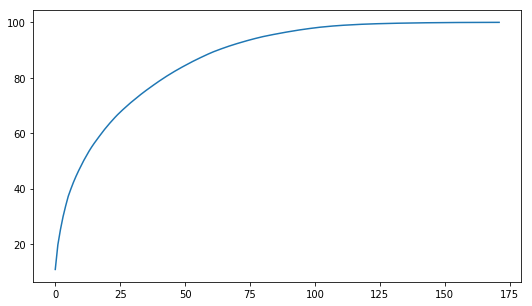

```python
# plot feature variance
features = range(pca.n_components_)
cumulative_variance = np.round(np.cumsum(pca.explained_variance_ratio_)*100, decimals=4)
plt.figure(figsize=(175/20,100/20)) # 100 elements on y-axis; 175 elements on x-axis; 20 is normalising factor
plt.plot(cumulative_variance)
```

## PCA and Logistic Regression

```python
# create pipeline
PCA_VARS = 60
steps = [('scaler', StandardScaler()),
         ("pca", PCA(n_components=PCA_VARS)),
         ("logistic", LogisticRegression(class_weight='balanced'))
        ]
pipeline = Pipeline(steps)
```

```python
# fit model
pipeline.fit(X_train, y_train)

# check score on train data
pipeline.score(X_train, y_train)
```

```
Pipeline(memory=None,
     steps=[('scaler', StandardScaler(copy=True, with_mean=True, with_std=True)), ('pca', PCA(copy=True, iterated_power='auto', n_components=60, random_state=None,
  svd_solver='auto', tol=0.0, whiten=False)), ('logistic', LogisticRegression(C=1.0, class_weight='balanced', dual=False,
          fit_intercept=True, intercept_scaling=1, max_iter=100,
          multi_class='ovr', n_jobs=1, penalty='l2', random_state=None,
          solver='liblinear', tol=0.0001, verbose=0, warm_start=False))])
```

```
0.8205333333333333
```

### Evaluate on test data

```python
# predict churn on test data
y_pred = pipeline.predict(X_test)

# create onfusion matrix
cm = confusion_matrix(y_test, y_pred)
print(cm)

# check sensitivity and specificity
sensitivity, specificity, _ = sensitivity_specificity_support(y_test, y_pred, average='binary')
print("Sensitivity: \t", round(sensitivity, 2), "\n", "Specificity: \t", round(specificity, 2), sep='')

# check area under curve
y_pred_prob = pipeline.predict_proba(X_test)[:, 1]
print("AUC:    \t", round(roc_auc_score(y_test, y_pred_prob),2))
```

```
[[5613 1278]
 [  91  519]]
Sensitivity: 	0.85
Specificity: 	0.81
AUC:    	 0.9
```

### Hyperparameter tuning - PCA and Logistic Regression

```python
# class imbalance
y_train.value_counts()/y_train.shape
```

```
0    0.918622
1    0.081378
Name: churn, dtype: float64
```

```python
# PCA
pca = PCA()

# logistic regression - the class weight is used to handle class imbalance - it adjusts the cost function
logistic = LogisticRegression(class_weight={0:0.1, 1: 0.9})

# create pipeline
steps = [("scaler", StandardScaler()),
         ("pca", pca),
         ("logistic", logistic)
        ]

# compile pipeline
pca_logistic = Pipeline(steps)

# hyperparameter space
params = {'pca__n_components': [60, 80], 'logistic__C': [0.1, 0.5, 1, 2, 3, 4, 5, 10], 'logistic__penalty': ['l1', 'l2']}

# create 5 folds
folds = StratifiedKFold(n_splits = 5, shuffle = True, random_state = 4)

# create gridsearch object
model = GridSearchCV(estimator=pca_logistic, cv=folds, param_grid=params, scoring='roc_auc', n_jobs=-1, verbose=1)
```

```python
# fit model
model.fit(X_train, y_train)
```

```
Fitting 5 folds for each of 32 candidates, totalling 160 fits
```

```
[Parallel(n_jobs=-1)]: Done  42 tasks      | elapsed:  3.0min
[Parallel(n_jobs=-1)]: Done 160 out of 160 | elapsed: 10.3min finished
```

```
GridSearchCV(cv=StratifiedKFold(n_splits=5, random_state=4, shuffle=True),
       error_score='raise',
       estimator=Pipeline(memory=None,
     steps=[('scaler', StandardScaler(copy=True, with_mean=True, with_std=True)), ('pca', PCA(copy=True, iterated_power='auto', n_components=None, random_state=None,
  svd_solver='auto', tol=0.0, whiten=False)), ('logistic', LogisticRegression(C=1.0, class_weight={0: ...y='l2', random_state=None,
          solver='liblinear', tol=0.0001, verbose=0, warm_start=False))]),
       fit_params=None, iid=True, n_jobs=-1,
       param_grid={'pca__n_components': [60, 80], 'logistic__C': [0.1, 0.5, 1, 2, 3, 4, 5, 10], 'logistic__penalty': ['l1', 'l2']},
       pre_dispatch='2*n_jobs', refit=True, return_train_score='warn',
       scoring='roc_auc', verbose=1)
```

```python
# cross validation results
pd.DataFrame(model.cv_results_)
```

|  | mean_fit_time | std_fit_time | mean_score_time | std_score_time | param_logistic__C | param_logistic__penalty | param_pca__n_components | params | split0_test_score | split1_test_score | split2_test_score | split3_test_score | split4_test_score | mean_test_score | std_test_score | rank_test_score | split0_train_score | split1_train_score | split2_train_score | split3_train_score | split4_train_score | mean_train_score | std_train_score |
| --- | --- | --- | --- | --- | --- | --- | --- | --- | --- | --- | --- | --- | --- | --- | --- | --- | --- | --- | --- | --- | --- | --- | --- |
| 0 | 14.310691 | 3.601207 | 0.082182 | 0.026817 | 0.1 | l1 | 60 | {'logistic__C': 0.1, 'logistic__penalty': 'l1'... | 0.893424 | 0.896388 | 0.879455 | 0.879650 | 0.889877 | 0.887759 | 0.007011 | 31 | 0.892666 | 0.891376 | 0.896544 | 0.895234 | 0.892728 | 0.893710 | 0.001890 |
| 1 | 16.386900 | 4.125111 | 0.097794 | 0.029306 | 0.1 | l1 | 80 | {'logistic__C': 0.1, 'logistic__penalty': 'l1'... | 0.897337 | 0.900268 | 0.880970 | 0.884409 | 0.891970 | 0.890991 | 0.007363 | 4 | 0.896789 | 0.895300 | 0.901144 | 0.899414 | 0.897095 | 0.897948 | 0.002071 |
| 2 | 13.135526 | 3.310098 | 0.077551 | 0.012029 | 0.1 | l2 | 60 | {'logistic__C': 0.1, 'logistic__penalty': 'l2'... | 0.893687 | 0.897616 | 0.878130 | 0.881052 | 0.887659 | 0.887629 | 0.007347 | 32 | 0.893948 | 0.892525 | 0.897778 | 0.896400 | 0.893911 | 0.894912 | 0.001901 |
| 3 | 12.918391 | 1.810922 | 0.065158 | 0.020049 | 0.1 | l2 | 80 | {'logistic__C': 0.1, 'logistic__penalty': 'l2'... | 0.898398 | 0.902419 | 0.879356 | 0.885687 | 0.888061 | 0.890785 | 0.008454 | 12 | 0.898696 | 0.897261 | 0.903302 | 0.901211 | 0.899328 | 0.899960 | 0.002098 |
| 4 | 11.820128 | 1.256941 | 0.080447 | 0.017170 | 0.5 | l1 | 60 | {'logistic__C': 0.5, 'logistic__penalty': 'l1'... | 0.893679 | 0.897867 | 0.878308 | 0.882753 | 0.887484 | 0.888018 | 0.007090 | 27 | 0.894088 | 0.892613 | 0.897908 | 0.896497 | 0.893941 | 0.895010 | 0.001916 |
| 5 | 13.521796 | 2.146524 | 0.073405 | 0.027843 | 0.5 | l1 | 80 | {'logistic__C': 0.5, 'logistic__penalty': 'l1'... | 0.898683 | 0.902399 | 0.880324 | 0.886327 | 0.888062 | 0.891159 | 0.008165 | 1 | 0.899092 | 0.897484 | 0.903248 | 0.901630 | 0.899408 | 0.900172 | 0.002028 |
| 6 | 12.641425 | 1.906088 | 0.099816 | 0.026067 | 0.5 | l2 | 60 | {'logistic__C': 0.5, 'logistic__penalty': 'l2'... | 0.893508 | 0.899112 | 0.879066 | 0.881703 | 0.887790 | 0.888236 | 0.007390 | 21 | 0.894371 | 0.893142 | 0.897970 | 0.896631 | 0.894203 | 0.895263 | 0.001767 |
| 7 | 14.712002 | 2.578477 | 0.084825 | 0.015302 | 0.5 | l2 | 80 | {'logistic__C': 0.5, 'logistic__penalty': 'l2'... | 0.898306 | 0.903206 | 0.878682 | 0.885838 | 0.887425 | 0.890692 | 0.008867 | 15 | 0.898902 | 0.897928 | 0.903264 | 0.901740 | 0.899956 | 0.900358 | 0.001926 |
| 8 | 13.321897 | 2.116156 | 0.058245 | 0.004616 | 1 | l1 | 60 | {'logistic__C': 1, 'logistic__penalty': 'l1', ... | 0.893752 | 0.898875 | 0.878751 | 0.881968 | 0.888902 | 0.888450 | 0.007390 | 17 | 0.893867 | 0.893071 | 0.897947 | 0.896748 | 0.893701 | 0.895067 | 0.001919 |
| 9 | 19.162462 | 3.309108 | 0.110470 | 0.019740 | 1 | l1 | 80 | {'logistic__C': 1, 'logistic__penalty': 'l1', ... | 0.898415 | 0.902568 | 0.879834 | 0.885961 | 0.886980 | 0.890752 | 0.008423 | 13 | 0.899063 | 0.897616 | 0.903631 | 0.901452 | 0.900046 | 0.900361 | 0.002059 |
| 10 | 15.568770 | 2.484354 | 0.118456 | 0.030634 | 1 | l2 | 60 | {'logistic__C': 1, 'logistic__penalty': 'l2', ... | 0.893823 | 0.898972 | 0.878438 | 0.882174 | 0.887813 | 0.888244 | 0.007476 | 19 | 0.894258 | 0.893140 | 0.898050 | 0.896597 | 0.893891 | 0.895187 | 0.001840 |
| 11 | 16.555754 | 3.087109 | 0.093842 | 0.048670 | 1 | l2 | 80 | {'logistic__C': 1, 'logistic__penalty': 'l2', ... | 0.898471 | 0.902412 | 0.879082 | 0.886062 | 0.887175 | 0.890641 | 0.008561 | 16 | 0.899074 | 0.897885 | 0.903625 | 0.901875 | 0.899692 | 0.900430 | 0.002057 |
| 12 | 13.754140 | 2.333608 | 0.088560 | 0.007758 | 2 | l1 | 60 | {'logistic__C': 2, 'logistic__penalty': 'l1', ... | 0.893921 | 0.898779 | 0.878671 | 0.881348 | 0.888282 | 0.888201 | 0.007515 | 23 | 0.894323 | 0.892967 | 0.898030 | 0.896559 | 0.893820 | 0.895140 | 0.001871 |
| 13 | 15.155681 | 3.357157 | 0.089516 | 0.022169 | 2 | l1 | 80 | {'logistic__C': 2, 'logistic__penalty': 'l1', ... | 0.898966 | 0.902460 | 0.879081 | 0.886981 | 0.887136 | 0.890925 | 0.008578 | 7 | 0.899210 | 0.897953 | 0.903529 | 0.901783 | 0.899590 | 0.900413 | 0.001988 |
| 14 | 12.302505 | 1.781586 | 0.127977 | 0.023032 | 2 | l2 | 60 | {'logistic__C': 2, 'logistic__penalty': 'l2', ... | 0.893610 | 0.898709 | 0.878416 | 0.881756 | 0.888094 | 0.888117 | 0.007443 | 25 | 0.894469 | 0.892913 | 0.897664 | 0.896557 | 0.894084 | 0.895137 | 0.001727 |
| 15 | 13.454204 | 1.996481 | 0.105238 | 0.037208 | 2 | l2 | 80 | {'logistic__C': 2, 'logistic__penalty': 'l2', ... | 0.898268 | 0.902804 | 0.878351 | 0.886818 | 0.887299 | 0.890709 | 0.008751 | 14 | 0.899081 | 0.897445 | 0.903544 | 0.901784 | 0.899959 | 0.900362 | 0.002119 |
| 16 | 12.951000 | 1.979778 | 0.093143 | 0.010151 | 3 | l1 | 60 | {'logistic__C': 3, 'logistic__penalty': 'l1', ... | 0.893289 | 0.898527 | 0.878555 | 0.881916 | 0.887464 | 0.887950 | 0.007284 | 28 | 0.894148 | 0.893027 | 0.897980 | 0.896552 | 0.894248 | 0.895191 | 0.001805 |
| 17 | 16.619931 | 1.967224 | 0.109135 | 0.021637 | 3 | l1 | 80 | {'logistic__C': 3, 'logistic__penalty': 'l1', ... | 0.898628 | 0.902376 | 0.879450 | 0.886585 | 0.887318 | 0.890872 | 0.008414 | 9 | 0.899131 | 0.897616 | 0.903484 | 0.901767 | 0.900087 | 0.900417 | 0.002042 |
| 18 | 14.536846 | 0.380587 | 0.117486 | 0.021496 | 3 | l2 | 60 | {'logistic__C': 3, 'logistic__penalty': 'l2', ... | 0.893738 | 0.899123 | 0.879517 | 0.882033 | 0.887556 | 0.888394 | 0.007261 | 18 | 0.894177 | 0.893071 | 0.898210 | 0.896649 | 0.894126 | 0.895247 | 0.001891 |
| 19 | 13.380017 | 1.889265 | 0.095545 | 0.035354 | 3 | l2 | 80 | {'logistic__C': 3, 'logistic__penalty': 'l2', ... | 0.898866 | 0.902649 | 0.879416 | 0.886365 | 0.887815 | 0.891023 | 0.008525 | 3 | 0.899471 | 0.897775 | 0.903534 | 0.901900 | 0.899861 | 0.900508 | 0.002003 |
| 20 | 11.994451 | 1.352483 | 0.094948 | 0.028318 | 4 | l1 | 60 | {'logistic__C': 4, 'logistic__penalty': 'l1', ... | 0.893966 | 0.898911 | 0.877446 | 0.881802 | 0.887219 | 0.887869 | 0.007810 | 30 | 0.894261 | 0.893171 | 0.897827 | 0.896871 | 0.894177 | 0.895261 | 0.001773 |
| 21 | 16.723633 | 3.029306 | 0.072407 | 0.014462 | 4 | l1 | 80 | {'logistic__C': 4, 'logistic__penalty': 'l1', ... | 0.898528 | 0.902414 | 0.879355 | 0.886375 | 0.887431 | 0.890821 | 0.008444 | 10 | 0.899230 | 0.897626 | 0.903557 | 0.901756 | 0.900330 | 0.900500 | 0.002041 |
| 22 | 13.356528 | 1.939683 | 0.080708 | 0.020965 | 4 | l2 | 60 | {'logistic__C': 4, 'logistic__penalty': 'l2', ... | 0.893570 | 0.899281 | 0.878542 | 0.881920 | 0.887885 | 0.888240 | 0.007542 | 20 | 0.894357 | 0.893352 | 0.898209 | 0.896745 | 0.894083 | 0.895349 | 0.001828 |
| 23 | 13.483160 | 0.887052 | 0.072303 | 0.021712 | 4 | l2 | 80 | {'logistic__C': 4, 'logistic__penalty': 'l2', ... | 0.898560 | 0.902273 | 0.880646 | 0.886212 | 0.887150 | 0.890969 | 0.008114 | 6 | 0.899205 | 0.897528 | 0.903465 | 0.901573 | 0.900341 | 0.900422 | 0.002022 |
| 24 | 13.005043 | 0.337982 | 0.062641 | 0.030045 | 5 | l1 | 60 | {'logistic__C': 5, 'logistic__penalty': 'l1', ... | 0.893744 | 0.898476 | 0.878238 | 0.882186 | 0.887586 | 0.888046 | 0.007376 | 26 | 0.894411 | 0.893062 | 0.898179 | 0.896843 | 0.894250 | 0.895349 | 0.001874 |
| 25 | 12.976811 | 1.922245 | 0.077721 | 0.020494 | 5 | l1 | 80 | {'logistic__C': 5, 'logistic__penalty': 'l1', ... | 0.898684 | 0.902680 | 0.879432 | 0.886790 | 0.886881 | 0.890894 | 0.008531 | 8 | 0.899308 | 0.897690 | 0.903725 | 0.901742 | 0.900332 | 0.900560 | 0.002063 |
| 26 | 13.359467 | 1.099991 | 0.066575 | 0.013857 | 5 | l2 | 60 | {'logistic__C': 5, 'logistic__penalty': 'l2', ... | 0.893511 | 0.899640 | 0.877654 | 0.881537 | 0.887154 | 0.887900 | 0.007942 | 29 | 0.893813 | 0.893291 | 0.898381 | 0.896782 | 0.893886 | 0.895230 | 0.001996 |
| 27 | 18.301420 | 2.926647 | 0.069415 | 0.011399 | 5 | l2 | 80 | {'logistic__C': 5, 'logistic__penalty': 'l2', ... | 0.898790 | 0.902698 | 0.879715 | 0.885569 | 0.887328 | 0.890820 | 0.008576 | 11 | 0.899473 | 0.897398 | 0.903409 | 0.901805 | 0.900378 | 0.900493 | 0.002042 |
| 28 | 13.718045 | 2.878132 | 0.083402 | 0.010016 | 10 | l1 | 60 | {'logistic__C': 10, 'logistic__penalty': 'l1',... | 0.893552 | 0.899799 | 0.878114 | 0.881440 | 0.887733 | 0.888128 | 0.007884 | 24 | 0.894107 | 0.892989 | 0.897929 | 0.896469 | 0.894097 | 0.895118 | 0.001807 |
| 29 | 15.753566 | 3.101451 | 0.057845 | 0.011195 | 10 | l1 | 80 | {'logistic__C': 10, 'logistic__penalty': 'l1',... | 0.899132 | 0.903060 | 0.879106 | 0.886311 | 0.887259 | 0.890974 | 0.008821 | 5 | 0.899526 | 0.897728 | 0.903472 | 0.901738 | 0.899985 | 0.900490 | 0.001963 |
| 30 | 15.261619 | 1.881416 | 0.095370 | 0.018967 | 10 | l2 | 60 | {'logistic__C': 10, 'logistic__penalty': 'l2',... | 0.894180 | 0.898879 | 0.878283 | 0.881726 | 0.887941 | 0.888202 | 0.007618 | 22 | 0.894552 | 0.893295 | 0.898006 | 0.896677 | 0.894319 | 0.895370 | 0.001717 |
| 31 | 12.812690 | 4.119737 | 0.078192 | 0.011503 | 10 | l2 | 80 | {'logistic__C': 10, 'logistic__penalty': 'l2',... | 0.898581 | 0.902501 | 0.880538 | 0.886811 | 0.887148 | 0.891116 | 0.008143 | 2 | 0.899398 | 0.897750 | 0.903282 | 0.901800 | 0.900202 | 0.900486 | 0.001913 |

```python
# print best hyperparameters
print("Best AUC: ", model.best_score_)
print("Best hyperparameters: ", model.best_params_)
```

```
Best AUC:  0.8911594701125283
Best hyperparameters:  {'logistic__C': 0.5, 'logistic__penalty': 'l1', 'pca__n_components': 80}
```

```python
# predict churn on test data
y_pred = model.predict(X_test)

# create onfusion matrix
cm = confusion_matrix(y_test, y_pred)
print(cm)

# check sensitivity and specificity
sensitivity, specificity, _ = sensitivity_specificity_support(y_test, y_pred, average='binary')
print("Sensitivity: \t", round(sensitivity, 2), "\n", "Specificity: \t", round(specificity, 2), sep='')

# check area under curve
y_pred_prob = model.predict_proba(X_test)[:, 1]
print("AUC:    \t", round(roc_auc_score(y_test, y_pred_prob),2))
```

```
[[5864 1027]
 [ 107  503]]
Sensitivity: 	0.82
Specificity: 	0.85
AUC:    	 0.91
```

The AUC score of the best model is 0.91